# Replicating the poverty treemap

Andrew Whitby

2017-11-10

I made the orginal poverty treemap (pages 2 and 3 of this rather [bulky PDF](https://openknowledge.worldbank.org/handle/10986/26306)) by actually post-processing the SVG generated by the `treemap` package, which was then hand-finished by graphic designers (you can read a little about that process [here](https://andrewwhitby.com/2017/05/06/comparative-treemaps/)).

That wasn’t an approach designed to be reuseable, whereas this one is, and should make it relatively easy to produce a reasonably good-looking comparative treemap using `ggplot2`.

## The side-by-side comparative form

We can use the data from the D3 animated treemap to make a first cut of the comparative treemaps. First we load the data and transform it as required.

```r
library(tidyr)
library(dplyr)
library(ggplot2)
library(ggtreemap)

xp <- read.csv("https://worldbank.github.io/wdi-sdg/sdg1/extreme_poverty.csv", stringsAsFactors = FALSE)

xp <- xp %>%
  gather("year", "num_poor", year_1990:year_2013) %>%
  mutate(year = substr(year, 6, 10))

# Generate the 2 year dataset
xp_2yr <- xp %>%
  filter(year %in% range(year))

# Generate max of the two years
xp_max_2yr <- xp_2yr %>%
  group_by(iso3c) %>%
  summarise(year_max_2yr = max(num_poor))

xp_2yr <- xp_2yr %>% left_join(xp_max_2yr)

knitr::kable(head(xp_2yr))
```

| country | iso3c | region | income_FY17 | region3c | year_max | year | num_poor | year_max_2yr |
| --- | --- | --- | --- | --- | --- | --- | --- | --- |
| Albania | ALB | Europe & Central Asia | Upper middle income | ECS | 0.098898 | 1990 | 0.003619 | 0.029580 |
| Angola | AGO | Sub-Saharan Africa | Upper middle income | SSF | 7.626078 | 1990 | 5.170998 | 6.434680 |
| Argentina | ARG | Latin America & Caribbean | High Income | LCN | 4.745408 | 1990 | 0.250536 | 0.680750 |
| Armenia | ARM | Europe & Central Asia | Lower middle income | ECS | 0.943263 | 1990 | 0.384444 | 0.384444 |
| Azerbaijan | AZE | Europe & Central Asia | Upper middle income | ECS | 0.524576 | 1990 | 0.044392 | 0.044392 |
| Bangladesh | BGD | South Asia | Lower middle income | SAS | 49.732098 | 1990 | 45.083893 | 45.083893 |

Then we can make a basic version of the treemap using standard ggplot.

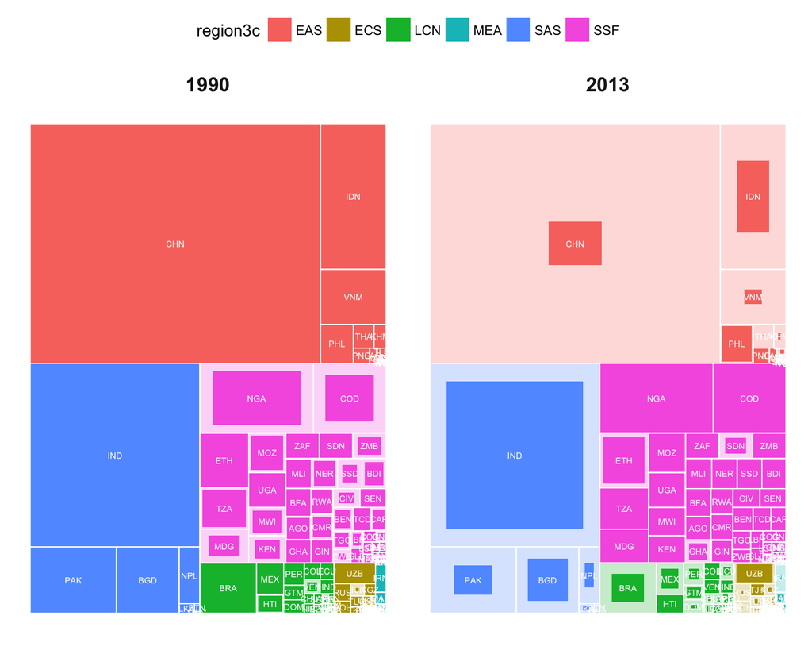

```r
# Only label those with > 0.25% of the max
np.total <- sum(xp_max_2yr$year_max_2yr)
iso3c_labelled <- xp_max_2yr$iso3c[xp_max_2yr$year_max_2yr / np.total > 0.0025]

ar <- 0.75
base_plot <- ggplot(xp_2yr, aes(area = num_poor, layout_area = year_max_2yr, fill = region3c, subgroup = region3c)) +
  geom_rect(aes(area = year_max_2yr), stat = "treemap", aspect.ratio = ar, color = NA, alpha = 0.25) +
  geom_rect(stat = "treemap", aspect.ratio = ar, color = NA) +
  geom_rect(aes(area = year_max_2yr), stat = "treemap", aspect.ratio = ar, color = "white", fill=NA, size = 0.35) +
  scale_y_reverse() +
  facet_wrap(~ year) +
  guides(fill = guide_legend(nrow = 1, direction = "horizontal"))

base_plot +
  geom_text(aes(label = iso3c),stat = "treemap", aspect.ratio = ar,color = "white", size = 2) +
  theme_minimal() +
  theme(axis.text = element_blank(), panel.grid = element_blank(),
        legend.position = "top", strip.text = element_text(size = rel(1.2), face = "bold"))
```

And finally, we can polish it using country names and colors from `wbgcharts`, an internal package that is (not yet) public. It’s not perfect - labels should be dark when over light areas, and some of the longer country names should be split over multiple lines.

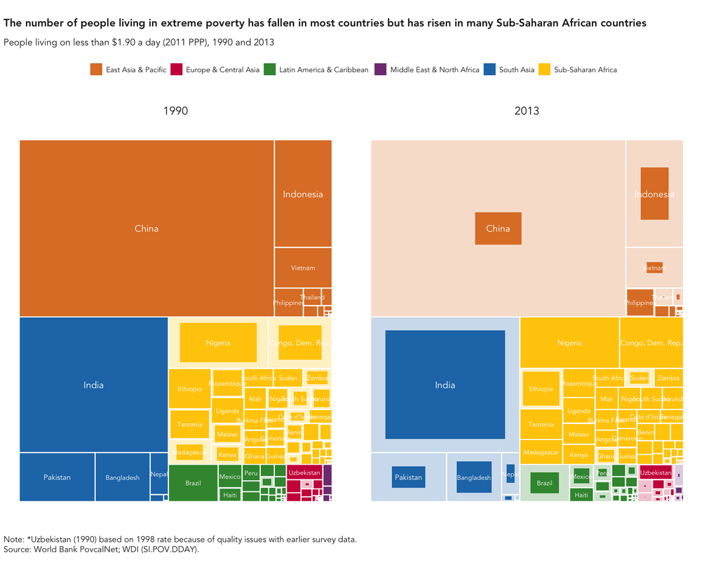

```r
if (require(wbgcharts)) {
  style <- style_atlas()
  finished_plot <- base_plot +
    geom_text(
      aes(
        label = ifelse(iso3c %in% iso3c_labelled, wbgref$countries$labels[iso3c], ""),
        size = cut(year_max_2yr,c(0,50,100,Inf))
      ),
      stat = "treemap", aspect.ratio = ar,
      color = "white",
      family = style$theme()$text$family
    ) +
    scale_size_manual(values = c(0.7,0.8,1)*style$gg_text_size, guide = "none") +
    scale_fill_manual(values = style$colors$regions, labels = wbgref$regions$labels) +
    labs(
      title = "The number of people living in extreme poverty has fallen in most countries but has risen in many Sub-Saharan African countries",
      subtitle = "People living on less than $1.90 a day (2011 PPP), 1990 and 2013",
      caption = "Note: *Uzbekistan (1990) based on 1998 rate because of quality issues with earlier survey data.\nSource: World Bank PovcalNet; WDI (SI.POV.DDAY)."
    ) +
    style$theme() +
    theme(axis.text = element_blank(), panel.grid = element_blank(),
        legend.position = "top", strip.text = element_text(size = rel(1.2), face = "bold"))
  print(finished_plot)
}
```